# EDA Code Notebook

Samantha Lim

2024-08-06

#### Introduction

##### The U.S. Department of Education College Scorecard dataset is a resource that provides detailed information about various higher education institutions across the United States. This dataset includes a wide range of variables, such as institutional characteristics, student demographics, academic programs, financial aid, and post-graduation outcomes. Our initial motivation for analyzing this dataset stems from the need to provide prospective students and educators with valuable insights into the performance and characteristics of U.S. colleges and universities. By examining factors such as admission rates, average SAT/ACT scores, tuition costs, graduation rates, and post-graduation earnings, we aim to evaluate institutional performance and promote transparency.

### ———————————–

#### Setup

#### Install and Load Necessary Packages

##### Let’s start by installing and loading the necessary packages. We will use renv for package management and tidyverse, dplyr, and ggplot2 for data manipulation and visualization. We will also use readr to read the dataset and scales to format labels.

```r
# Install and load necessary packages

library(renv) # Package management
library(tidyverse) # Data manipulation and visualization
```

```r
library(dplyr) # Data manipulation
library(readr) # Read dataset
library(ggplot2) # Data visualization
library(scales) # Format labels
# Initialize renv to manage dependencies
renv::snapshot()
```

```
## - The lockfile is already up to date.
```

```r
renv::restore()
```

```
## - The library is already synchronized with the lockfile.
```

```r
renv::hydrate()
```

```
## - No new packages were discovered in this project; nothing to do.
```

#### Load the Dataset

##### We will load the College Scorecard dataset, which provides information about higher education institutions in the United States. This dataset includes variables related to tuition, student demographics, and post-graduation outcomes.

```r
# load dataset
# source: https://collegescorecard.ed.gov/data/
# technical documentation and explanation of dataset: https://collegescorecard.ed.gov/assets/InstitutionDataDocumentation.pdf

data <- read_csv("Data/Most-Recent-Cohorts-Institution.csv")
# Display the first few rows of the dataset
head(data)
```

```
## # A tibble: 6 × 3,305
##   UNITID OPEID    OPEID6 INSTNM   CITY  STABBR ZIP   ACCREDAGENCY INSTURL NPCURL
##    <dbl> <chr>    <chr>  <chr>    <chr> <chr>  <chr> <chr>        <chr>   <chr>
## 1 100654 00100200 001002 Alabama… Norm… AL     35762 Southern As… www.aa… www.a…
## 2 100663 00105200 001052 Univers… Birm… AL     3529… Southern As… https:… https…
## 3 100690 02503400 025034 Amridge… Mont… AL     3611… Southern As… https:… https…
## 4 100706 00105500 001055 Univers… Hunt… AL     35899 Southern As… www.ua… finai…
## 5 100724 00100500 001005 Alabama… Mont… AL     3610… Southern As… www.al… www.a…
## 6 100751 00105100 001051 The Uni… Tusc… AL     3548… Southern As… www.ua… finan…
## # ℹ 3,295 more variables: SCH_DEG <dbl>, HCM2 <dbl>, MAIN <dbl>,
## #   NUMBRANCH <dbl>, PREDDEG <dbl>, HIGHDEG <dbl>, CONTROL <dbl>,
## #   ST_FIPS <dbl>, REGION <dbl>, LOCALE <dbl>, LOCALE2 <lgl>, LATITUDE <dbl>,
## #   LONGITUDE <dbl>, CCBASIC <dbl>, CCUGPROF <dbl>, CCSIZSET <dbl>, HBCU <dbl>,
## #   PBI <dbl>, ANNHI <dbl>, TRIBAL <dbl>, AANAPII <dbl>, HSI <dbl>,
## #   NANTI <dbl>, MENONLY <dbl>, WOMENONLY <dbl>, RELAFFIL <dbl>,
## #   ADM_RATE <dbl>, ADM_RATE_ALL <dbl>, SATVR25 <dbl>, SATVR75 <dbl>, …
```

##### The specific variables found in this dataset include the following:

##### Institutional Information:

##### - Institution name

##### - Location (city, state, ZIP code)

##### - Type of institution (public, private nonprofit, private for-profit)

##### - Level of institution (4-year, 2-year, less-than-2-year)

##### Admissions:

##### - Acceptance rate

##### - SAT/ACT scores (25th and 75th percentiles)

##### - Admissions requirements

##### Enrollment:

##### - Total enrollment

##### - Undergraduate and graduate enrollment

##### - Demographic breakdown (age, gender, race/ethnicity)

##### Financial Information:

##### - Average annual cost (net price) for different income levels

##### - Tuition and fees

##### - Financial aid (average amount of aid received, percentage of students receiving aid)

##### - Student loan data (median debt, repayment rates)

##### Outcomes:

##### - Graduation rates (overall, by gender, by race/ethnicity)

##### - Retention rates (first-year)

##### - Employment outcomes (median earnings 10 years after enrollment)

##### - Loan repayment rates (3-year, 5-year, 7-year)

##### Academic Programs:

##### - Popular majors and programs offered

##### - Average earnings by program

##### Faculty and Class Size:

##### - Student-to-faculty ratio

##### - Percentage of full-time faculty

##### Campus Safety:

##### - Reported on-campus crime statistics

### ———————————–

#### Data Preparation

#### Data Cleaning

##### We’ll start by performing some initial data cleaning. The dataset contains 6,484 entries and 3305 total columns, so we will need to narrow down the variables of interest.

```r
# Select variables of interest: instituition type, graduation rates, retention rates, tuition costs, admission rates, financial aid, median earnings
data <- data[, c("INSTNM", "CONTROL", "STABBR", "C100_4", "C100_L4", "RET_FT4", "RET_FTL4", "TUITFTE", "ADM_RATE", "PCTFLOAN_DCS", "MD_EARN_WNE_P10")]

# Rename variables
names(data) <- c("INSTNM", "INST", "STABBR", "GRAD_4", "GRAD<4", "RET_4", "RET<4", "TUITFTE", "ADM_RATE", "PCTFLOAN", "MD_EARN_WNE_P10")
```

##### Variables

###### INSTNM: institution name

###### INST: type of institution (public, private non-profit, or private for-profit)

###### STABBR: state abbreviation

###### GRAD_4: graduation rate for 4-year institutions

###### GRAD<4: graduation rate for less-than-4-year institutions

###### RET_4: retention rate for full-time students at 4-year institutions

###### RET<4: retention rate for full-time students at less-than-4-year institutions

###### TUITFTE: tuition revenue per full-time equivalent (FTE) student

###### ADM_RATE: admission rate

###### PCTFLOAN: proportion of graduates who have received a federal loan

###### MD_EARN_WNE_P10: median earnings 10 years after enrollment

### ———————————–

#### Analysis

#### Institution Type

##### In this dataset, there are three types of institutions: public, private non-profit, and private for-profit. The main difference in the three consistently connect back to their funding sources, governance structures, and missions.

##### 1) Public Institutions, such as state universities or community colleges, are primarily funded from their state or local government, meaning tuition costs are considerably cheaper as taxpayers are funding students academic and extracurricular programs. Public schools are focused on providing accessible education to their residents.

##### 2) Private Non-Profit Institutions are funded through those who attend and pay tuition fees, alumni or other individuals who donate or provide endowments, in addition to grants the school may have applied for. They are considered “non-profit” because all revenue made from these funds are reinvested in the institution for its students. These boards of trustees or directors have more autonomy compared to public institutions. Many of these schools may have mission statements related to religious or service-oriented values. They are highly focused on academics. These schools include the Ivy Leagues, which are the top universities nationwide, liberal arts schools, and universities that have religious affiliations.

##### 3) Private For-Profit Institutions operate as businesses. They primarily generate revenue from the tuition and fees students pay, and aim to make a profit. As a result, the corporate boards are held accountable to investors or shareholders. These institutions focus on providing skill sets that will aid their students in being placed in the workforce after graduating. They oftentimes offer programs in high-demand, specialized. These institutions include online universities, technical and vocational schools.

##### Additionally, it is important to note that many schools offer programs that are two years long, typically for an Associate’s Degree, or four-years long for a Bachelor’s Degree. The case may differ for technical or vocational schools, as they have their own timelines for students to master the hands-on skills they are attending for. These include topics relating to trade skills (automotive technology, welding, plumbing, electricians). Health care (nursing, medical or dental assisting, phlebotomy), information technology (computer programming, network administration, cybersecurity, web development), Business and office administration (accounting, office management, paralegal studies), Creative and design fields ( graphic design, culinary arts, fashion design, interior design), skilled trades (construction, hvac, Machining), and personal services ( cosmetology, massage therapy, Aesthetics).

### ———————————–

##### Now that you have a better understanding of how each institution works and what their missions are, we can dive into what their graduation rates look like and understand why they are so.

##### Graduation Rates by Institution Type

##### Now, we will calculate and compare the average graduation rates for 4-year and less-than-4-year institutions by institution type.

```r
# Calculate average graduation rates for 4-year institutions by institution type
grad_rates_4 <- data %>%
  group_by(factor(INST, levels = c(1, 2, 3), labels = c("Public", "Private Non-Profit", "Private For-Profit"))) %>%
  summarize(avg_grad_rate = mean(GRAD_4, na.rm = TRUE))

# Print the results
print("Average Graduation Rates for 4-Year Institutions:")
```

```
## [1] "Average Graduation Rates for 4-Year Institutions:"
```

```r
print(grad_rates_4)
```

```
## # A tibble: 3 × 2
##   `factor(...)`      avg_grad_rate
##   <fct>                      <dbl>
## 1 Public                     0.341
## 2 Private Non-Profit         0.440
## 3 Private For-Profit         0.331
```

```r
# Calculate average graduation rates for less-than-4-year institutions by institution type
grad_rates_less_4 <- data %>%
  group_by(factor(INST, levels = c(1, 2, 3), labels = c("Public", "Private Non-Profit", "Private For-Profit"))) %>%
  summarize(avg_grad_rate = mean(`GRAD<4`, na.rm = TRUE))

# Print the results
print("Average Graduation Rates for Less-Than-4-Year Institutions:")
```

```
## [1] "Average Graduation Rates for Less-Than-4-Year Institutions:"
```

```r
print(grad_rates_less_4)
```

```
## # A tibble: 3 × 2
##   `factor(...)`      avg_grad_rate
##   <fct>                      <dbl>
## 1 Public                     0.325
## 2 Private Non-Profit         0.485
## 3 Private For-Profit         0.328
```

##### Findings: In both four-year and less than four-year institutions, public and private for-profit institutions have similar graduation rates while private non-profit institutions have higher graduation rates. Private non-profit institutions have graduation rates nearly ten percent more. These findings may lead students to look for private non-profit universities when considering college applications or decisions.

### ———————————–

##### Retention Rates by Institution Type

##### College retention rates indicate how many students stay at the same institution from year to year. High rates suggest student satisfaction and effective support. Larger public universities often have lower retention rates, while private non-profit schools typically have higher rates due to better support and financial aid. Private for-profit institutions usually have lower rates, often due to issues with program quality and support.

##### Now, we will calculate and compare the average retention rates for 4-year and less-than-4-year institutions by institution type.

```r
# Calculate average retention rates for 4-year institutions by institution type
retention_rates_4 <- data %>%
  group_by(factor(INST, levels = c(1, 2, 3), labels = c("Public", "Private Non-Profit", "Private For-Profit"))) %>%
  summarize(avg_ret_rate_4 = mean(RET_4, na.rm = TRUE))

# Calculate average retention rates for less-than-4-year institutions by institution type
retention_rates_less_4 <- data %>%
  group_by(factor(INST, levels = c(1, 2, 3), labels = c("Public", "Private Non-Profit", "Private For-Profit"))) %>%
  summarize(avg_ret_rate_less_4 = mean(`RET<4`, na.rm = TRUE))

# Print the results
print("Average Retention Rates for 4-Year Institutions:")
```

```
## [1] "Average Retention Rates for 4-Year Institutions:"
```

```r
print(retention_rates_4)
```

```
## # A tibble: 3 × 2
##   `factor(...)`      avg_ret_rate_4
##   <fct>                       <dbl>
## 1 Public                      0.723
## 2 Private Non-Profit          0.740
## 3 Private For-Profit          0.608
```

```r
print("Average Retention Rates for Less-Than-4-Year Institutions:")
```

```
## [1] "Average Retention Rates for Less-Than-4-Year Institutions:"
```

```r
print(retention_rates_less_4)
```

```
## # A tibble: 3 × 2
##   `factor(...)`      avg_ret_rate_less_4
##   <fct>                            <dbl>
## 1 Public                           0.648
## 2 Private Non-Profit               0.695
## 3 Private For-Profit               0.743
```

##### Findings

##### Four-year private non-profit institutions have the highest retention rates, followed closely by four-year public institutions. Retention rates for four-year private for-profit universities are significantly lower, suggesting tuition pricing and other factors may influence student retention because private for-profit tuition fees are significantly higher than public tuition fees. For less-than-four-year institutions, private for-profit institutions have the highest retention rates, followed by private non-profit and public institutions.

### ———————————–

##### Tuition Costs by Institution Type

##### Here are the main differences in tuition costs. It is important to keep in mind that many fees are not included in the tuition rate, such as meal plans, housing, and access to class materials.

##### Public Institutions

##### Public colleges and universities typically have different tuition rates for in-state and out-of-state students. In-state students typically pay $10,000 per year for tuition and fees, summing up to $40,000 after four years while out-of-state students pay $25,000 to $30,000, or between $100,000 and $120,000 in total. These institutions benefit from state funding, which helps keep costs lower for in-state residents.

##### Private Non-Profit Institutions

##### The tuition for private non-profit institutions is definitely higher. Students pay between $35,000 and $55,000 per year. Over the course of a four-year degree, the total cost can range from $140,000 to $220,000. Many students apply for financial aid and scholarships to be able to attend.

##### Private For-Profit Institutions

##### The tuition at private for-profit institutions usually have annual tuition and fees ranging from $15,000 to $25,000, summing up to $60,000 to $100,000. Costs can vary widely depending on the specific program and institution. For-profit institutions often cater to non-traditional students with flexible schedules and online options, which may impact the overall cost.

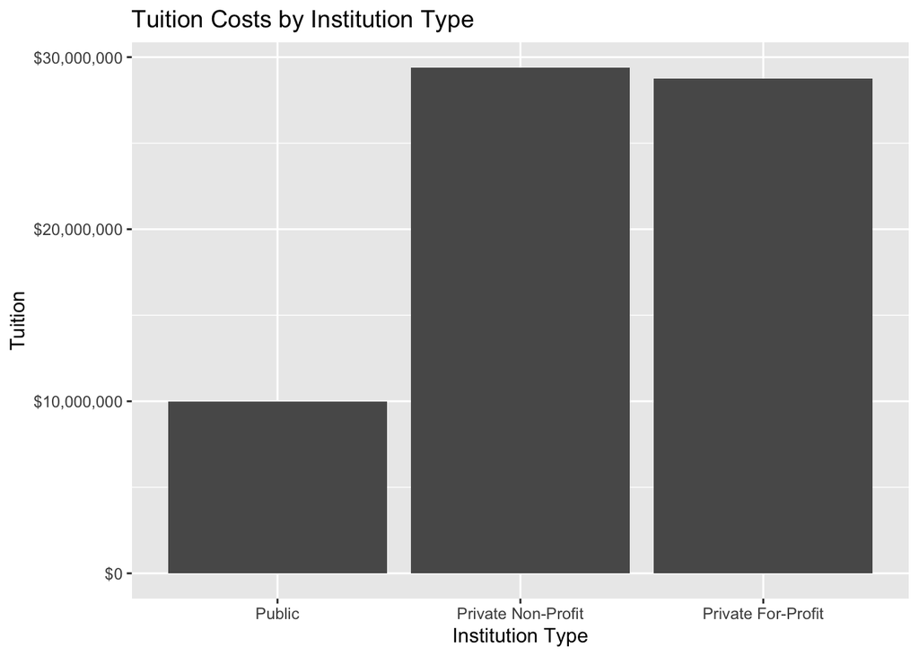

```r
# Plot tuition costs by institution type
# Re-label the institution types
ggplot(data, aes(x = factor(INST, levels = c(1, 2, 3), labels = c("Public", "Private Non-Profit", "Private For-Profit")), y = TUITFTE)) +  # Ensure correct ordering and labeling
  geom_col() +
  # Include title, x-axis label, and y-axis label
  labs(title = "Tuition Costs by Institution Type", x = "Institution Type", y = "Tuition") +
  # Format the y-axis labels as dollar amounts
  scale_y_continuous(labels = dollar)
```

##### Findings: As demonstrated in the chart above, there are drastic differences in tuition based on each type of institution. Private Non-Profit Institutions and Private For-Profit Institutions are similarly placed, whereas Public Institutions are significantly cheaper since they are partly funded through the public government – they are typically less than half the price of their counterparts. This is a significant factor that many students and their families take into consideration when applying to and choosing the college they eventually attend. Retention rates and tuition costs vary significantly by institution type. Public institutions tend to be more affordable, which might contribute to higher retention rates compared to private for-profit institutions. These insights can inform policy decisions and help students make more informed choices about their education.

### ———————————–

##### Admission Rates by Institution Type

##### We will compare admission rates across different types of institutions to see how they vary.

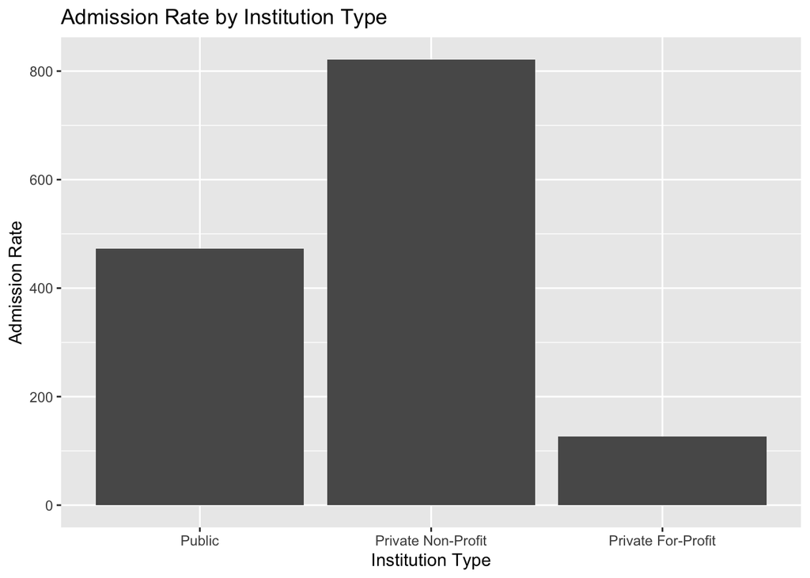

```r
# Plot admission rates by institution type
ggplot(data, aes(x = factor(INST, levels = c(1, 2, 3), labels = c("Public", "Private Non-Profit", "Private For-Profit")), y = ADM_RATE)) +
  geom_col() +
  # Include title, x-axis label, and y-axis label
  labs(title = "Admission Rate by Institution Type", x = "Institution Type", y = "Admission Rate")
```

##### Findings: Institution Type 2 has the highest admission rate, while Type 3 has the lowest. This may be surprising because numerous prestigious private non-profit universities have low acceptance rates.

### ———————————–

##### Financial Aid by Institution Type

##### Next, we visualize the percentage of students receiving federal loans by institution type.

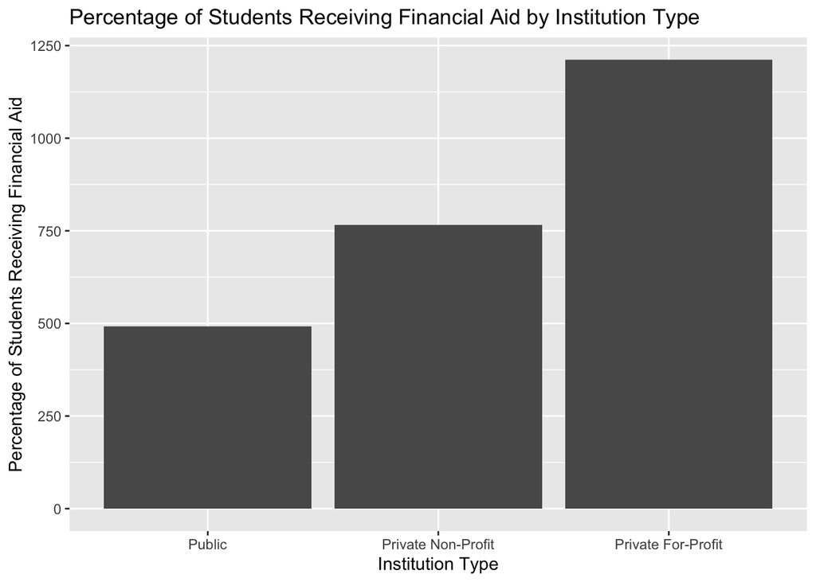

```r
# Plot percentage of students receiving financial aid by institution type
ggplot(data, aes(x = factor(INST, levels = c(1, 2, 3), labels = c("Public", "Private Non-Profit", "Private For-Profit")), y = PCTFLOAN)) +
  geom_col() +
  # Include title, x-axis label, and y-axis label
  labs(title = "Percentage of Students Receiving Financial Aid by Institution Type", x = "Institution Type", y = "Percentage of Students Receiving Financial Aid")
```

##### Findings: Private for-profit institutions have the largest proportion of students receiving financial aid, followed by private non-profit and public institutions. This may be the result in funding and allotment of financial aid. In contrast, government funded public schools may not have the budget to allow more financial aid, regardless of the fact that their tuition is cheaper compared to private schools.

### ———————————–

##### Median Earnings by Institution Type

##### We will now visualize the median earnings of graduates 10 years after enrollment by institution type.

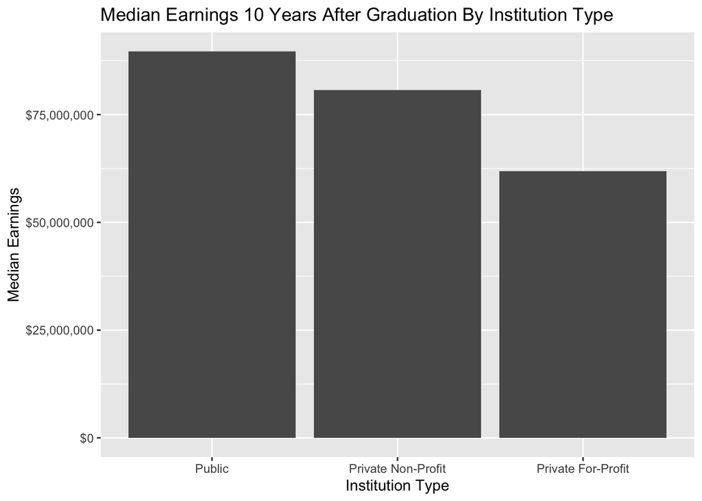

```r
# Plot Median Earnings 10 Years After Enrollment By Institution Type
ggplot(data, aes(x = factor(INST, levels = c(1, 2, 3), labels = c("Public", "Private Non-Profit", "Private For-Profit")), y = MD_EARN_WNE_P10)) +
  geom_col() +
  # Include title, x-axis label, and y-axis label
  labs(title = "Median Earnings 10 Years After Graduation By Institution Type", x = "Institution Type", y = "Median Earnings") +
  # Format the y-axis labels as dollar amounts
  scale_y_continuous(labels = dollar)
```

##### Findings: Students who attend public institutions generally earn the highest median incomes 10 years after enrollment, followed closely by those from private non-profit and private for-profit institutions. This suggests that tuition costs might not directly impact future earnings as expected. However, if students have taken out loans, the lower tuition at public institutions means they have less debt to repay over time. Private for-profit institutions offer specialized vocational training, but graduates often earn less than those with college degrees in fields like medicine. When choosing a school, students should consider not only tuition costs and potential loan repayments but also the cost of living and other financial factors. Additionally, differences in school size, location, and enrollment can significantly affect median earnings post-graduation.

### ———————————–

##### Top 10 States by Admission Rate

##### We will calculate and visualize the states with the highest admission rates.

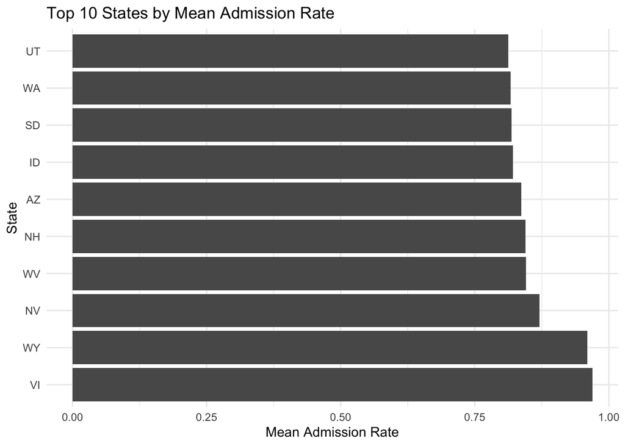

```r
# Calculate the mean admission rate by state
state_adm_rate <- data %>%
  # Filter by state
  group_by(STABBR) %>%
  # Sort by mean admission rate
  summarise(mean_adm_rate = mean(ADM_RATE, na.rm = TRUE))

# Select the top 10 states by mean admission rate
top_10_states <- state_adm_rate %>%
  # Arrange entries from highest to lowest admission rate
  arrange(desc(mean_adm_rate)) %>%
  head(10)

# Plot the top 10 states by mean admission rate
ggplot(top_10_states, aes(x = reorder(STABBR, -mean_adm_rate), y = mean_adm_rate)) +
  geom_bar(stat = "identity") +
  coord_flip() +  # Flip coordinates for better readability
  # Include title, x-axis label, and y-axis label
  labs(title = "Top 10 States by Mean Admission Rate",
       x = "State",
       y = "Mean Admission Rate") +
  theme_minimal()
```

### ———————————–

##### Top 10 States with the Lowest Admission Rate

##### We will calculate and visualize the states with the lowest admission rates.

```r
# Select the top 10 states by lowest mean admission rate
# Use the state_adm_rate of the mean admission rate per state calculated beforehand
top_10_states_low <- state_adm_rate %>%
  arrange(mean_adm_rate) %>%
  head(10)

# View the top 10 states
print(top_10_states_low)
```

```
## # A tibble: 10 × 2
##    STABBR mean_adm_rate
##    <chr>          <dbl>
##  1 DE             0.621
##  2 MA             0.631
##  3 VT             0.640
##  4 DC             0.645
##  5 CA             0.647
##  6 RI             0.655
##  7 FL             0.668
##  8 GA             0.681
##  9 NC             0.686
## 10 OK             0.688
```

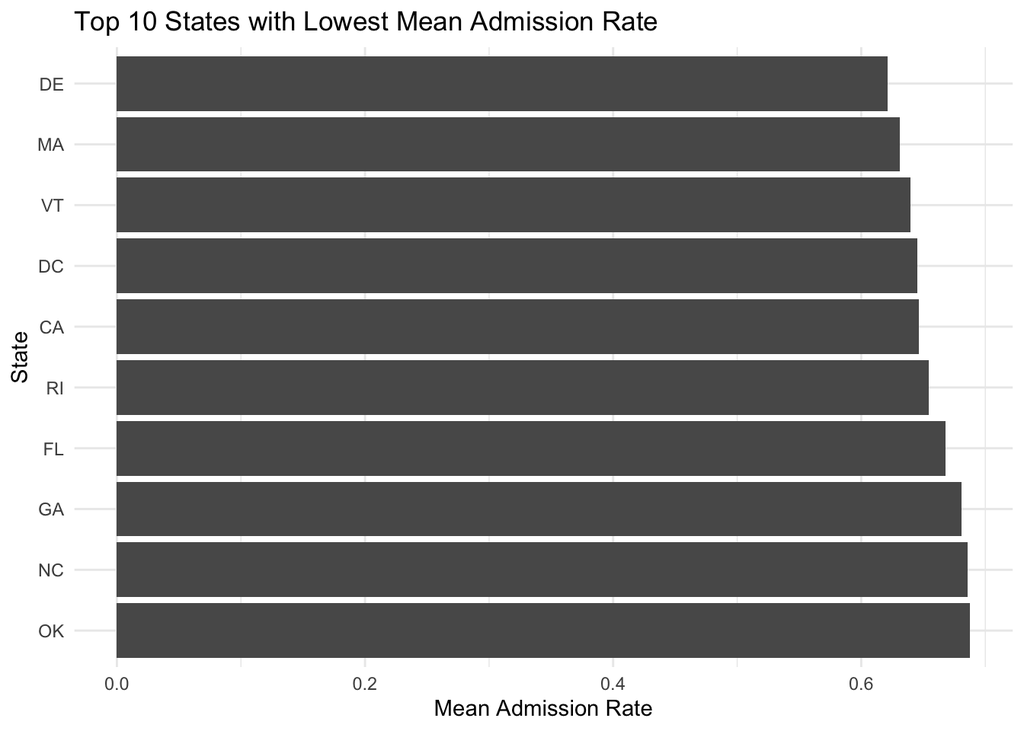

```r
# Plot the states by mean admission rate
ggplot(top_10_states_low, aes(x = reorder(STABBR, -mean_adm_rate), y = mean_adm_rate)) +
  geom_bar(stat = "identity") +
  coord_flip() +  # Flip coordinates for better readability
  # Include title, x-axis label, and y-axis label
  labs(title = "Top 10 States with Lowest Mean Admission Rate",
       x = "State",
       y = "Mean Admission Rate") +
  theme_minimal()
```

### ———————————–

##### Median Earnings by State

##### In this section, we calculate and visualize the top 10 states with the highest median earnings 10 years after graduation.

```r
# Calculate the median earnings 10 years post-grad by state
state_earn_rate <- data %>%
  # Filter data by state
  group_by(STABBR) %>%
  # Calculate the average median earnings per state
  summarise(mean_med_earn_rate = mean(MD_EARN_WNE_P10, na.rm = TRUE))

# View the aggregated data
head(state_earn_rate)
```

```
## # A tibble: 6 × 2
##   STABBR mean_med_earn_rate
##   <chr>               <dbl>
## 1 AK                 44295.
## 2 AL                 40117.
## 3 AR                 34790.
## 4 AS                 30087
## 5 AZ                 43303.
## 6 CA                 46875.
```

```r
# Select the top 10 states by lowest mean admission rate
# Use state_earn_rate variable calculated beforehand
top_10_earn_states <- state_earn_rate %>%
  # Sort by median earnings from highest to lowest
  arrange(desc(mean_med_earn_rate)) %>%
  # Select the top 10 states with the highest median earnings
  head(10)

# View the top 10 states
print(top_10_earn_states)
```

```
## # A tibble: 10 × 2
##    STABBR mean_med_earn_rate
##    <chr>               <dbl>
##  1 MA                 58803.
##  2 RI                 56328.
##  3 CT                 53719.
##  4 DC                 52165.
##  5 NH                 52126.
##  6 NY                 51733.
##  7 PA                 50059.
##  8 WA                 49381.
##  9 NJ                 48471.
## 10 ME                 48367.
```

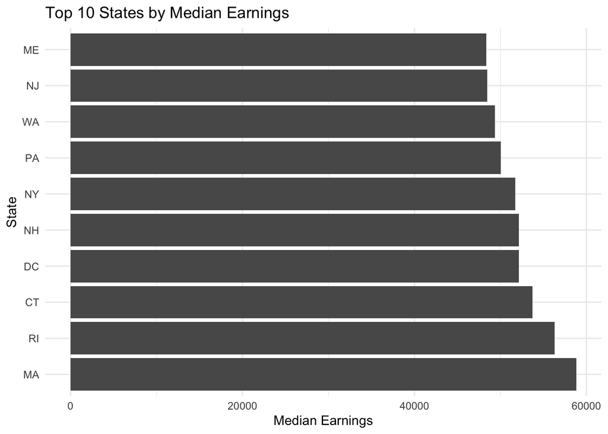

```r
# Plot the top 10 states by mean admission rate
ggplot(top_10_earn_states, aes(x = reorder(STABBR, -mean_med_earn_rate), y = mean_med_earn_rate)) +
  geom_bar(stat = "identity") +
  coord_flip() +  # Flip coordinates for better readability
  # Include title, x-axis label, and y-axis label
  labs(title = "Top 10 States by Median Earnings",
       x = "State",
       y = "Median Earnings") +
  theme_minimal()
```

### ———————————–

##### Association Between Financial Aid and Tuition Cost

##### We will now create a scatter plot to visualize the relationship between the percentage of students receiving financial aid and tuition costs.

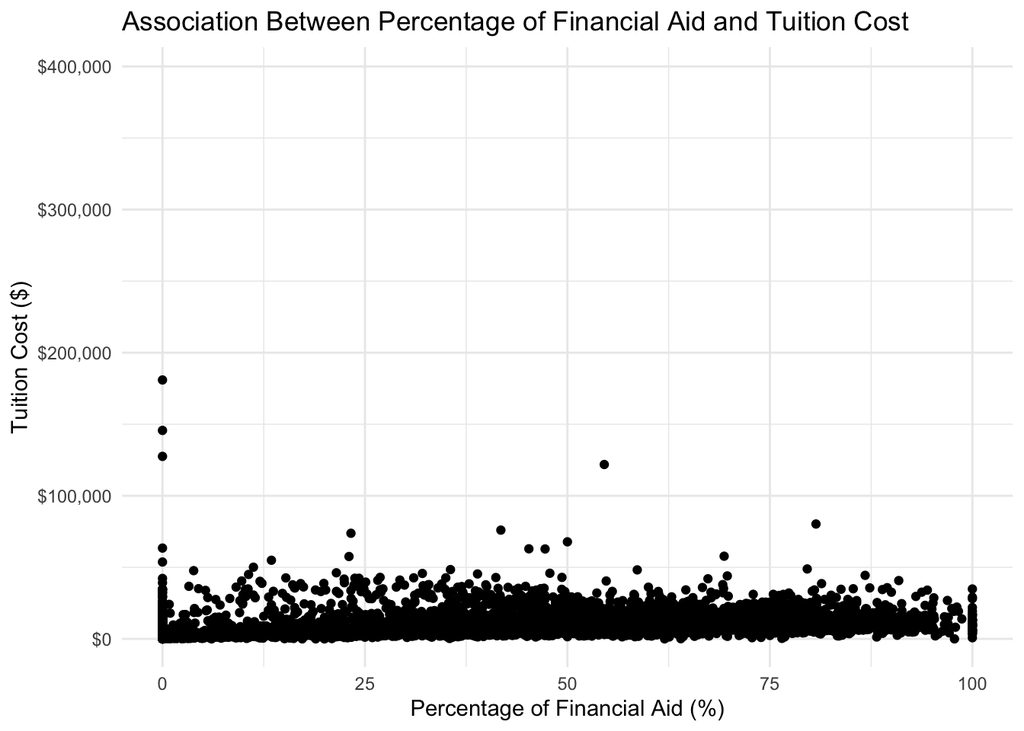

```r
# Scatter plot of percentage of financial aid vs. tuition cost
ggplot(data, aes(x = PCTFLOAN * 100, y = TUITFTE)) +  # Convert percentage to 0-100 scale
  geom_point() +
  # Include title, x-axis label, and y-axis label
  labs(title = "Association Between Percentage of Financial Aid and Tuition Cost",
       x = "Percentage of Financial Aid (%)",
       y = "Tuition Cost ($)") +
  theme_minimal() +
  # Format the y-axis labels as dollar amounts
  scale_y_continuous(labels = dollar)
```

##### Findings: This scatter plot implies that the tuition cost does not have a huge impact on the percentage of financial aid. However, there are some outliers on the left side of the chart showing that when the percentage of the financial aid is closer to zero percent, the tuition is higher. There are also a few outliers near the 50% and 75% range where it is seen that with more financial aid coverage, the tuition cost is still relatively high.

### ———————————–

##### Schools with the Highest Post-Graduate Earnings

##### We will identify the top 10 schools with the highest median earnings 10 years after graduation and analyze their tuition costs.

```r
# Schools with the Highest Post Graduate Earnings

# Select variables (institution name, median earnings, tuition fees) from dataset
top_10_earnings <- data[, c("INSTNM", "MD_EARN_WNE_P10", "TUITFTE")] %>%
  # Sort new entries by median earnings from highest to lowest
  arrange(desc(MD_EARN_WNE_P10)) %>%
  # Select top 10 schools with highest earnings
  head(10)
print(top_10_earnings)
```

```
## # A tibble: 10 × 3
##    INSTNM                                                MD_EARN_WNE_P10 TUITFTE
##    <chr>                                                           <dbl>   <dbl>
##  1 Massachusetts Institute of Technology                          143372   35084
##  2 Samuel Merritt University                                      143238   35207
##  3 Philadelphia College of Osteopathic Medicine                   138767   41459
##  4 Harvey Mudd College                                            138687   36122
##  5 University of Health Sciences and Pharmacy in St. Lo…          137047   31126
##  6 Albany College of Pharmacy and Health Sciences                 131426   25674
##  7 Franklin W Olin College of Engineering                         129455   19005
##  8 California Institute of Technology                             128566   21222
##  9 MCPHS University                                               125557   24083
## 10 Stanford University                                            124080   28879
```

### ———————————–

##### Schools with the Largest Difference in Cost and Post-Graduate Earnings (Best Value)

##### We will now find the schools with the largest difference between post-graduate earnings and tuition costs, highlighting the best value schools.

```r
# Schools with the largest difference in cost and post-graduate earnings (best value)

# select variables (institution name, median earnings, tuition fees) from dataset
earn_diff <- data[, c("INSTNM", "MD_EARN_WNE_P10", "TUITFTE")] %>%
  # create new column recording the difference between cost and median earnings
  mutate(diff = data[["MD_EARN_WNE_P10"]]-(data[["TUITFTE"]]*4)) %>%
  # Sort new entries by difference from highest to lowest
  arrange(desc(diff)) %>%
  # Select top 10 schools with largest difference
  head(10)

print(earn_diff)
```

```
## # A tibble: 10 × 4
##    INSTNM                                          MD_EARN_WNE_P10 TUITFTE  diff
##    <chr>                                                     <dbl>   <dbl> <dbl>
##  1 Los Angeles County College of Nursing and Alli…          115318    4215 98458
##  2 United States Merchant Marine Academy                     90610       0 90610
##  3 Jewish Theological Seminary of America                    92751    4620 74271
##  4 The University of Texas MD Anderson Cancer Cen…           90232    4473 72340
##  5 Miami Ad School-Atlanta                                  106192    8809 70956
##  6 Heritage Valley Kennedy School of Nursing                 79831    3313 66579
##  7 Phillips School of Nursing at Mount Sinai Beth…           96980    7612 66532
##  8 University of Connecticut-Stamford                        73997    1870 66517
##  9 University of Connecticut-Hartford Campus                 73997    2562 63749
## 10 University of Connecticut-Waterbury Campus                73997    2730 63077
```

### ———————————–

##### Relationship Between Tuition and Median Earnings

##### We will create a scatter plot to visualize the relationship between tuition costs and median earnings 10 years after graduation.

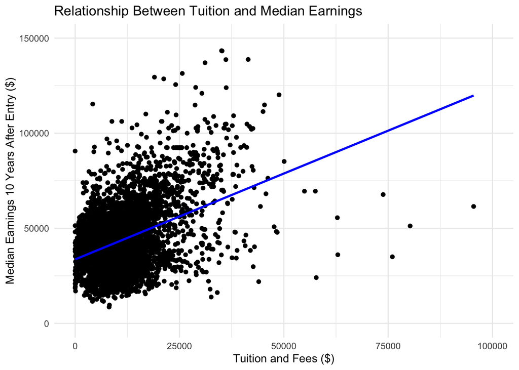

```r
# Earnings vs. Tuition and Fees
# Independent Variable: Tuition and Fees
# Dependent Variable: Median Earnings

# Plot relationship between tuition and median earnings
ggplot(data, aes(x = TUITFTE, y = MD_EARN_WNE_P10)) +
  geom_point() +
  # Include range for x-axis and y-axis
  xlim(0,100000) +
  ylim(0,150000) +
  geom_smooth(method = "lm", se = FALSE, color = "blue") +
  # Include title, x-axis label, and y-axis label
  labs(title = "Relationship Between Tuition and Median Earnings",
       x = "Tuition and Fees ($)",
       y = "Median Earnings 10 Years After Entry ($)") +
  theme_minimal()
```

##### Findings: This linear regression explores how the cost of education impacts future earnings. There seems to be a positive linear relationship between tuition fees and median earnings, suggesting higher earnings with more expensive institutions.

### ———————————–

##### Relationship Between Median Earnings and Admission Rate

##### We will create a scatter plot to explore the relationship between admission rates and median earnings 10 years after graduation.

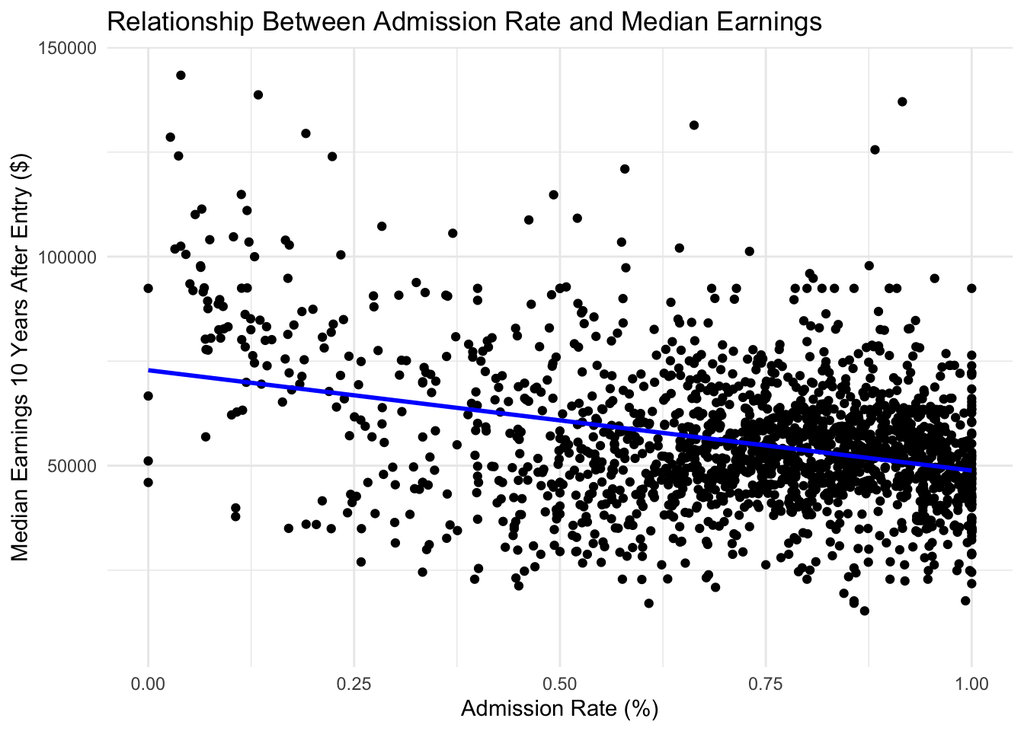

```r
# Earnings vs. Admission Rate
# Independent Variable: Admission Rate
# Dependent Variable: Median Earnings

# Plot
ggplot(data, aes(x = ADM_RATE, y = MD_EARN_WNE_P10)) +
  geom_point() +
  geom_smooth(method = "lm", se = FALSE, color = "blue") +
  # Include title, x-axis label, and y-axis label
  labs(title = "Relationship Between Admission Rate and Median Earnings",
       x = "Admission Rate (%)",
       y = "Median Earnings 10 Years After Entry ($)") +
  theme_minimal()
```

##### Findings: This linear regression examines whether more selective institutions or those with lower admission rates produce graduates with higher earnings. There is a slight negative linear relationship between median earnings and admission rate, suggesting that selective institutions yield graduates with higher earnings.

### ———————————–

#### Conclusion

##### While selectivity and prestige play a role in earnings, it is also evident that the specific programs offered by institutions significantly impact post-graduate salaries. Fields such as nursing, engineering, and other medical careers consistently show high earnings, highlighting the importance of program specialization in determining financial outcomes.

##### Further exploration is needed to understand how affordability affects post-graduate earnings. Specifically, we should consider whether the accessibility of education influences students’ career success and financial stability after graduation.